# ICB Data Curation Workflow

Minoru Nakano, Farnoosh Babazadeh, Sisira Nair

Sun/11/Sep

This RMarkdown script shows an example of ICB dataset curation workflow starting from curation to end analysis.

## Introduction

### Data Curation Overview

We take data from published studies and curated them into standardized data objects to be used for integrated data analyses.

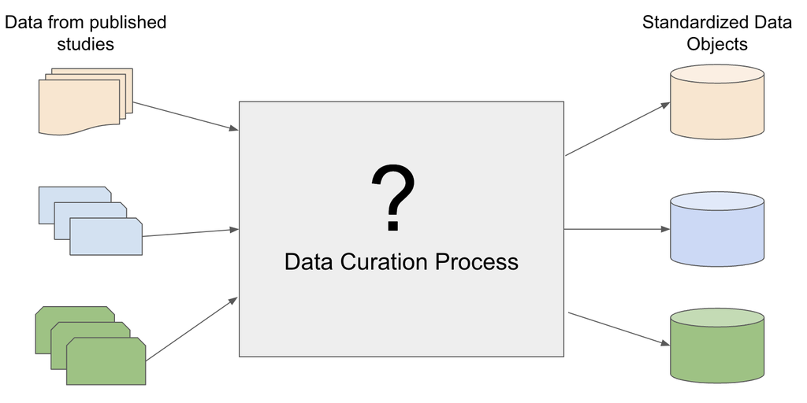

**Standardized data curation resolves inconsistencies across different datasets:**

- Various data formats: txt, csv, tsv, Excel, GEO…
- Various identifiers: “patientid” = “patient-id” = “id” = “patient” = “unique_patient_id”
- Unfriendly format: Newline characters, spaces, other unconventional characters
- Multiple data parts: patient/sample metadata, multiple assay data (RNA-seq, SNV…)

**The standardized data are integrated into MultiAssayExperiment object:**

[figure not shown]

MultiAssayExperiment:

1. An R data object structure designed to hold multiple assay data for a set of patients/samples.
2. Assay data can be in other R data structures such as SummarizedExperiment.
3. Flexible: The data structure can handle assays with different number of observations.
4. Comes with functions to work with the data.

### Data Curation Process

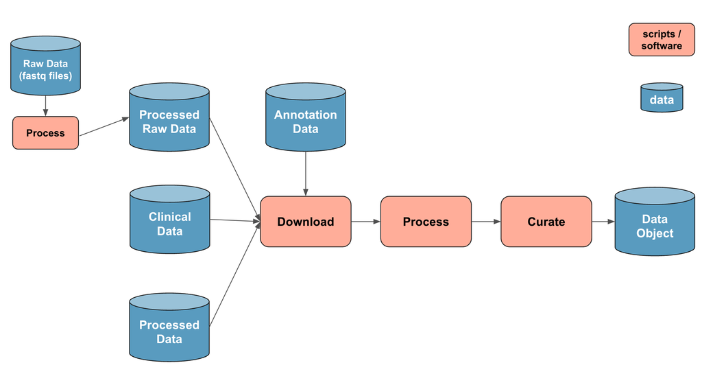

### ORCESTRA: Platform to Manage Data Curation Pipeline Executions

The ICB dataset curation pipelines were integrated and executed using the platform.

[figure not shown]

1. Each pipeline run is recorded and executed with a version controlled scripts.
2. Uses Snakemake to manage each step in a pipeline execution.
3. Establishes a clear association between the data and the version of code used to generate the data.
4. Provides a web interface to increase data accessibility. [www.orcestra.ca](https://www.orcestra.ca/)

## Data Curation Example: VanDenEnde

The scripts uses ICB_VanDenEnde data curation pipeline as an example. The rest of the datasets follow the same workflow.  
The pipeline is available in: ICB_VanDenEnde-snakemake  
There are common functions used across all ICB dataset curation pipelines which are available in ICB_Common  
The pipeline is organized in 4 steps:

1. Downloads data from the publication source
2. Formats the downloaded data
3. Processes the formatted data into common data format across all ICB datasets
4. Creates MultiAssayExperiment object

```r
library(data.table)
library(GEOquery)
library(Biobase)
library(SummarizedExperiment)
library(MultiAssayExperiment)
library(GenomicRanges)
library(biomaRt)
library(stringr)
library(readxl)
library(tximport)
library(knitr)
```

```r
options(timeout=1000)

#' Before run, please add folder - Data and sub folders : download, annotation, processed, RDS and TSV
study <- 'VanDenEnde'
download_dir <- '~/Data/download'
annotation_dir <- '~/Data/annotation'
processed_dir <- '~/Data/processed'
rds_dir <- '~/Data/RDS'
tsv_dir <- '~/Data/TSV'
```

### 1. Download Source and Annotation Data

Publication: https://pubmed.ncbi.nlm.nih.gov/33504550/  
Data source: https://www.ncbi.nlm.nih.gov/geo/query/acc.cgi?acc=GSE165252

```r
#' 1.1 Download source data
download.file(
  url='https://ftp.ncbi.nlm.nih.gov/geo/series/GSE165nnn/GSE165252/matrix/GSE165252_series_matrix.txt.gz',
  destfile = file.path(download_dir, 'GSE165252_series_matrix.txt.gz')
)
download.file(
  url='https://ftp.ncbi.nlm.nih.gov/geo/series/GSE165nnn/GSE165252/suppl/GSE165252_norm.cnt_PERFECT.txt.gz',
  destfile = file.path(download_dir, 'GSE165252_norm.cnt_PERFECT.txt.gz')
)

#' Download annotation files
#' Gene annotation data is kept in https://github.com/BHKLAB-DataProcessing/Annotations
#' Tissue and drug annotations for the ICB data are in https://github.com/BHKLAB-DataProcessing/ICB_Common/tree/main/data

#' 1.2 Download gene annotation data
download.file(
  url='https://github.com/BHKLAB-DataProcessing/Annotations/blob/master/Gencode.v19.annotation.RData?raw=true',
  destfile = file.path(annotation_dir, 'Gencode.v19.annotation.RData')
)

#' 1.3 Download tissue and drug annotation data
download.file(
  url='https://github.com/BHKLAB-DataProcessing/ICB_Common/raw/main/data/curation_drug.csv',
  destfile = file.path(annotation_dir, 'curation_drug.csv')
)
download.file(
  url='https://github.com/BHKLAB-DataProcessing/ICB_Common/raw/main/data/curation_tissue.csv',
  destfile = file.path(annotation_dir, 'curation_tissue.csv')
)
```

### 2. Format downloaded source data.

This step extracts clinical and expression data from the source data format and parses them into more processing-friendly format.

```r
commandArgs <- function(trailingOnly = TRUE){ return(c(download_dir)) }
source('https://raw.githubusercontent.com/BHKLAB-DataProcessing/ICB_VanDenEnde-snakemake/main/scripts/format_downloaded_data.R')
```

```
## Using locally cached version of GPL20301 found here:
## ~/Data/download/GPL20301.soft.gz
```

In the end, it produces two files extracted from the download source data: CLIN.txt and EXPR.txt.gz.

### 3. Process the formatted data to common data format across all ICB datasets

```r
commandArgs <- function(trailingOnly = TRUE){ return(c(download_dir, processed_dir, annotation_dir)) }
source('https://raw.githubusercontent.com/BHKLAB-DataProcessing/ICB_VanDenEnde-snakemake/main/scripts/Format_Data.R')
```

In the end, it produces three files:

1. CLIN.csv,
2. EXPR.csv and
3. cased_sequenced.csv, a file that indicates which patient has which molecular profiles. In this case, all patients will have EXPR data only.

### 4. Create MultiAssayExperiment object

```r
load(file.path(annotation_dir, "Gencode.v19.annotation.RData"))
source("https://raw.githubusercontent.com/BHKLAB-DataProcessing/ICB_Common/main/code/get_MultiAssayExp.R")
multi_assay_exp <- get_MultiAssayExp(study = study, input_dir = processed_dir)
```

**Data object is uploaded to Zenodo and made avaialble on ORCESTRA platform**: [ICB Datasets on ORCESTRA](https://www.orcestra.ca/clinical_icb)

### Using a MultiAssayExperiment Object

**Get a list of experiments included in this object**

```r
assays(multi_assay_exp)
```

```
## List of length 1
## names(1): expr
```

**Get patient metadata**

```r
coldata <- colData(multi_assay_exp)[, c('patientid', 'cancer_type', 'response', 'treatment')]
kable(coldata, caption='Patient metadata')
```

Patient metadata

|  | patientid | cancer_type | response | treatment |
| --- | --- | --- | --- | --- |
| GSM5033946 | GSM5033946 | Esophageal | NR | PD-1/PD-L1 |
| GSM5033948 | GSM5033948 | Esophageal | NR | PD-1/PD-L1 |
| GSM5033951 | GSM5033951 | Esophageal | R | PD-1/PD-L1 |
| GSM5033952 | GSM5033952 | Esophageal | R | PD-1/PD-L1 |
| GSM5033953 | GSM5033953 | Esophageal | R | PD-1/PD-L1 |
| GSM5033955 | GSM5033955 | Esophageal | NR | PD-1/PD-L1 |
| GSM5033958 | GSM5033958 | Esophageal | NR | PD-1/PD-L1 |
| GSM5033960 | GSM5033960 | Esophageal | NR | PD-1/PD-L1 |
| GSM5033962 | GSM5033962 | Esophageal | R | PD-1/PD-L1 |
| GSM5033964 | GSM5033964 | Esophageal | NR | PD-1/PD-L1 |
| GSM5033966 | GSM5033966 | Esophageal | NR | PD-1/PD-L1 |
| GSM5033969 | GSM5033969 | Esophageal | R | PD-1/PD-L1 |
| GSM5033972 | GSM5033972 | Esophageal | NR | PD-1/PD-L1 |
| GSM5033975 | GSM5033975 | Esophageal | R | PD-1/PD-L1 |
| GSM5033976 | GSM5033976 | Esophageal | NR | PD-1/PD-L1 |
| GSM5033978 | GSM5033978 | Esophageal | NR | PD-1/PD-L1 |
| GSM5033981 | GSM5033981 | Esophageal | NA | PD-1/PD-L1 |
| GSM5033982 | GSM5033982 | Esophageal | R | PD-1/PD-L1 |
| GSM5033985 | GSM5033985 | Esophageal | R | PD-1/PD-L1 |
| GSM5033987 | GSM5033987 | Esophageal | NR | PD-1/PD-L1 |
| GSM5033989 | GSM5033989 | Esophageal | NA | PD-1/PD-L1 |
| GSM5033991 | GSM5033991 | Esophageal | NR | PD-1/PD-L1 |
| GSM5033993 | GSM5033993 | Esophageal | NR | PD-1/PD-L1 |
| GSM5033998 | GSM5033998 | Esophageal | NR | PD-1/PD-L1 |
| GSM5034001 | GSM5034001 | Esophageal | R | PD-1/PD-L1 |
| GSM5034004 | GSM5034004 | Esophageal | NR | PD-1/PD-L1 |
| GSM5034007 | GSM5034007 | Esophageal | NR | PD-1/PD-L1 |
| GSM5034008 | GSM5034008 | Esophageal | NR | PD-1/PD-L1 |
| GSM5034010 | GSM5034010 | Esophageal | R | PD-1/PD-L1 |
| GSM5034011 | GSM5034011 | Esophageal | NR | PD-1/PD-L1 |
| GSM5034012 | GSM5034012 | Esophageal | R | PD-1/PD-L1 |
| GSM5034013 | GSM5034013 | Esophageal | R | PD-1/PD-L1 |
| GSM5034015 | GSM5034015 | Esophageal | NR | PD-1/PD-L1 |
| GSM5034017 | GSM5034017 | Esophageal | NA | PD-1/PD-L1 |
| GSM5034019 | GSM5034019 | Esophageal | NR | PD-1/PD-L1 |

**View EXPR data assay**

```r
expr <- experiments(multi_assay_exp)[['expr']]
assay <- assays(expr)[['expr']]
kable(assay[1:20, ], caption='Gene expresison data')
```

Gene expresison data

|  | GSM5033982 | GSM5033975 | GSM5033946 | GSM5033948 | GSM5033951 | GSM5033952 | GSM5033953 | GSM5033955 | GSM5033958 | GSM5033960 | GSM5033962 | GSM5033964 | GSM5033966 | GSM5033969 | GSM5033972 | GSM5033976 | GSM5033978 | GSM5033981 | GSM5033985 | GSM5033987 | GSM5033989 | GSM5033991 | GSM5033993 | GSM5033998 | GSM5034001 | GSM5034004 | GSM5034007 | GSM5034008 | GSM5034010 | … |
| --- | --- | --- | --- | --- | --- | --- | --- | --- | --- | --- | --- | --- | --- | --- | --- | --- | --- | --- | --- | --- | --- | --- | --- | --- | --- | --- | --- | --- | --- | --- |
| ENSG00000003056.3 | 6.8420142 | 6.0962270 | 7.2852418 | 5.3752621 | 4.7401881 | 5.5351274 | 6.5693615 | 5.9731071 | 7.8350254 | 4.0545355 | 8.3565196 | 6.8458517 | 6.7272073 | 6.7551986 | 7.5723795 | 7.8619639 | 5.7225263 | 8.4042613 | 6.8684154 | 5.7976867 | 8.0804037 | 4.3199334 | 5.6234330 | 7.9848212 | 8.0565819 | 6.3920168 | 5.3339834 | 6.4575942 | 3.9137448 | … |
| ENSG00000005073.5 | 1.2507238 | -1.4990647 | -9.9657843 | 1.4105213 | 2.5389390 | -3.8389928 | 0.6673935 | -9.9657843 | 4.5142981 | -0.5083861 | 5.1730102 | 3.3304796 | -0.0128435 | -0.6107898 | 3.3372652 | 3.9043812 | 2.9718203 | 3.8664014 | 0.3027794 | -2.2732029 | 3.7398128 | 1.1173221 | -0.9016852 | 4.1182483 | 1.1753306 | -1.6175378 | 0.7492577 | -0.1753258 | 2.0692787 | … |
| ENSG00000006116.3 | -9.9657843 | -5.8797070 | -9.9657843 | -9.9657843 | -9.9657843 | -9.9657843 | -9.9657843 | -9.9657843 | -9.9657843 | -9.9657843 | -9.9657843 | -9.9657843 | -9.9657843 | -3.4389343 | -9.9657843 | -9.9657843 | -9.9657843 | -4.2292308 | -9.9657843 | -9.9657843 | -9.9657843 | -9.9657843 | -9.9657843 | -9.9657843 | -9.9657843 | -6.2605111 | -9.9657843 | -5.1730159 | -9.9657843 | … |
| ENSG00000008197.4 | -9.9657843 | -9.9657843 | -9.9657843 | -9.9657843 | -9.9657843 | -9.9657843 | -9.9657843 | -9.9657843 | -9.9657843 | -9.9657843 | -9.9657843 | -9.9657843 | -9.9657843 | -9.9657843 | -9.9657843 | -9.9657843 | -9.9657843 | -5.9801230 | -9.9657843 | -9.9657843 | -9.9657843 | -9.9657843 | -9.9657843 | -9.9657843 | -9.9657843 | -9.9657843 | -9.9657843 | -9.9657843 | -9.9657843 | … |
| ENSG00000019995.6 | 6.9109907 | 6.5930865 | 6.4917721 | 4.9260521 | 4.4852437 | 4.3282927 | 6.1210013 | 7.1910952 | 8.7265096 | 4.0619252 | 7.8680150 | 6.4269918 | 6.3663711 | 5.6500622 | 6.8424861 | 6.8833262 | 4.9671560 | 6.4946311 | 6.5149002 | 6.1382163 | 7.2974958 | 6.7539717 | 5.0052606 | 6.5821821 | 7.4122598 | 6.0280582 | 4.9735456 | 5.9849736 | 4.3824433 | … |
| ENSG00000039139.9 | 7.5145928 | 9.0116579 | 6.1108844 | 3.7128729 | 5.7734372 | 3.2699000 | 4.7892305 | 4.1955356 | 3.9555491 | 2.2100191 | 11.1171861 | 9.4242234 | 3.4011291 | 5.4291139 | 7.5730284 | 6.2690521 | 5.8069570 | 5.2761466 | 5.6801402 | 5.3766259 | 6.1682683 | 3.2519928 | 4.3601547 | 4.0999594 | 7.8238293 | 7.8113861 | 6.2352782 | 6.6750304 | -9.9657843 | … |
| ENSG00000053328.8 | 1.0034844 | 0.1512628 | 0.7139017 | 2.0883040 | -3.7918287 | 0.4497326 | 0.6324713 | 0.3475023 | 2.7619731 | -0.8141473 | -0.4029639 | 1.0754006 | 1.9124978 | 0.3417649 | 1.2253164 | 3.6422091 | 1.8044736 | 1.2023376 | 2.1849057 | 2.2212242 | 0.4174654 | -9.9657843 | -1.9825245 | 2.4363185 | -1.4900667 | 1.0053866 | 2.1953748 | 2.3244407 | -9.9657843 | … |
| ENSG00000060303.5 | -9.9657843 | -9.9657843 | 1.2209121 | -9.9657843 | -1.3939916 | -9.9657843 | -0.2744798 | -9.9657843 | 0.6956866 | -1.7196929 | 3.3879385 | 1.9531973 | -1.2249364 | 0.0557368 | -0.0035481 | 1.3938395 | -1.5055958 | -0.6298210 | 2.6321498 | -9.9657843 | 2.2458883 | -9.9657843 | -9.9657843 | 1.2658513 | -0.0784390 | 1.1564426 | 1.2313246 | -0.0151144 | -9.9657843 | … |
| ENSG00000063515.2 | -9.9657843 | -9.9657843 | -9.9657843 | -9.9657843 | -9.9657843 | -9.9657843 | -2.6560822 | -9.9657843 | -9.9657843 | -9.9657843 | -9.9657843 | -9.9657843 | -9.9657843 | -9.9657843 | -4.3639568 | -9.9657843 | -9.9657843 | -9.9657843 | -9.9657843 | -3.7345691 | -9.9657843 | -9.9657843 | -9.9657843 | -9.9657843 | -9.9657843 | -9.9657843 | -9.9657843 | -9.9657843 | -1.4881833 | … |
| ENSG00000064195.7 | -9.9657843 | -1.4653929 | 2.3246646 | -6.0990030 | -8.3941905 | -7.6293311 | -1.2315735 | -1.8614848 | -6.7312517 | -6.9519447 | -5.9980910 | -0.8644579 | -1.5222398 | -6.7807393 | -3.4479774 | -0.1307294 | -9.0302798 | -4.1499162 | -2.1147278 | -9.9657843 | -5.4055571 | -4.8362832 | -9.9657843 | -7.1085935 | 2.3152243 | -2.4700886 | -8.1836672 | -1.6517615 | -9.9657843 | … |
| ENSG00000065491.8 | 4.4116171 | 5.0820306 | 5.5634476 | 4.1763231 | 3.9114413 | 3.5721796 | 4.8780586 | 6.2807995 | 5.6304575 | 1.9335131 | 6.0395578 | 5.7086513 | 5.3719671 | 4.1548933 | 5.1991204 | 6.3038363 | 4.4427628 | 5.6882182 | 5.5282960 | 5.1452378 | 5.7546527 | 3.3262541 | 3.0422111 | 5.4057945 | 6.3512288 | 4.8571542 | 3.7905343 | 4.7587900 | 4.2353962 | … |
| ENSG00000070193.4 | 0.9837953 | -3.5085740 | 0.8461287 | 1.0648394 | -2.9836904 | -1.2489372 | 1.4164618 | -1.6396823 | 0.5529856 | -3.8852965 | -2.2656145 | 1.1496647 | 1.0603773 | -1.6639633 | 0.7204493 | 1.4509621 | 0.7351116 | 0.4843350 | 0.2138004 | 0.5692044 | -0.7119803 | -0.3549993 | -9.9657843 | 3.2368875 | 1.6767656 | -0.0989814 | 1.5257028 | 1.9978634 | -9.9657843 | … |
| ENSG00000071677.1 | -2.0183883 | -9.9657843 | -9.9657843 | -9.9657843 | 0.1281455 | -9.9657843 | -9.9657843 | -9.9657843 | -9.9657843 | -9.9657843 | -9.9657843 | -9.9657843 | -9.9657843 | -9.9657843 | -9.9657843 | -9.9657843 | -9.9657843 | -9.9657843 | -9.9657843 | -9.9657843 | -9.9657843 | -9.9657843 | -9.9657843 | -9.9657843 | -9.9657843 | -9.9657843 | 2.4336618 | -9.9657843 | -9.9657843 | … |
| ENSG00000072315.3 | -1.1723480 | -2.0225311 | -2.4574004 | -2.4609496 | -3.6501622 | -2.6212521 | -2.5384216 | 0.8532971 | -0.5736572 | -4.9497641 | 1.1722873 | -0.5501281 | -1.3253692 | -2.2095649 | -1.4642555 | 1.4924355 | -1.3172684 | 1.1423911 | -0.6364400 | 0.0662933 | 0.1986327 | -9.9657843 | -9.9657843 | -2.3200562 | -3.3359230 | -9.9657843 | 0.4971839 | 0.4143481 | -9.9657843 | … |
| ENSG00000072444.10 | -9.9657843 | -2.5626002 | -9.9657843 | -9.9657843 | -3.1978344 | -9.9657843 | -9.9657843 | -1.8549423 | -1.1154207 | -9.9657843 | -9.9657843 | -3.1694104 | 1.2068947 | -9.9657843 | -9.9657843 | -1.9992382 | -9.9657843 | -9.9657843 | 1.3597024 | -9.9657843 | -9.9657843 | -9.9657843 | -9.9657843 | -2.8595134 | -9.9657843 | -9.9657843 | -1.3160045 | -2.8196967 | -9.9657843 | … |
| ENSG00000073905.8 | 2.2899408 | 2.0221620 | 3.7369768 | 1.9966958 | 1.1194516 | 1.5725435 | 2.2406549 | 1.7332188 | 3.8281440 | -1.5256453 | 4.7400434 | 3.9549201 | 2.9665195 | 2.2492990 | 3.8901893 | 3.0031552 | 3.0070569 | 4.0221127 | 4.0676586 | -0.1686535 | 4.8997115 | 0.9054170 | 2.2058474 | 3.3860361 | 4.0216637 | 2.9355937 | 1.6888394 | 2.6377378 | -9.9657843 | … |
| ENSG00000076641.4 | 4.2877693 | 5.3311790 | 3.8157940 | 4.8620243 | 4.1686725 | 3.9535614 | 4.0089579 | 3.5989779 | 5.6531585 | 2.3243676 | 4.4875379 | 5.4828759 | 3.9173128 | 4.0804951 | 6.0394545 | 5.6041793 | 4.5290262 | 5.4495724 | 3.7444590 | 5.5743509 | 5.3384930 | 2.6154807 | 5.1008318 | 5.6884840 | 5.0352501 | 3.6200066 | 3.1221489 | 5.3935065 | 4.4307681 | … |
| ENSG00000081842.13 | -3.1091273 | -2.2306784 | -1.6698094 | -2.6687726 | -5.7950368 | -9.9657843 | -4.7174259 | -3.5099581 | 0.3592161 | -9.9657843 | 0.1631837 | -2.6696322 | -9.9657843 | -1.2125139 | -3.4685978 | -2.3420731 | -2.1754738 | -5.0626775 | -2.3000546 | -0.5944785 | -0.6468552 | -9.9657843 | -3.0418077 | -1.7242100 | -2.5511452 | -5.5753137 | -1.5666009 | -5.4325437 | -0.2592644 | … |
| ENSG00000083622.8 | 0.0459315 | -9.9657843 | -1.6735593 | -0.6794254 | -0.1247512 | -1.2545703 | -2.1681889 | -9.9657843 | 0.7971641 | -2.0320395 | -9.9657843 | 0.6402512 | 0.0445500 | 2.5311752 | -0.9007610 | -9.9657843 | 2.2925742 | 1.3769291 | 1.5964287 | -9.9657843 | -1.2344418 | -9.9657843 | -9.9657843 | 0.2160287 | -0.9755853 | -2.0585724 | -1.9839618 | -0.3282601 | -9.9657843 | … |
| ENSG00000089163.4 | -2.2476051 | -2.4724624 | -1.8022096 | -2.9799634 | -1.8352114 | -4.2249348 | -2.7962130 | -1.3002925 | -1.9551735 | -4.6332776 | -1.2948178 | -1.3307286 | -1.8462684 | -1.6984159 | -1.6236951 | -1.1741357 | -2.0338216 | -0.1161398 | -1.7676745 | -1.6679825 | -1.4504360 | -2.3973858 | -2.8711320 | -1.3606182 | -1.2373671 | -2.0656332 | -1.6780380 | -1.7006171 | -3.2048988 | … |

**View Gene Metadata for the Genes in the EXPR assay**

```r
rowdata <- rowData(expr)
kable(rowdata[1:20, ], caption='Gene metadata')
```

Gene metadata

|  | source | type | score | phase | gene_id | gene_type | gene_name | level | havana_gene | tag | gene_id_no_ver | length |
| --- | --- | --- | --- | --- | --- | --- | --- | --- | --- | --- | --- | --- |
| ENSG00000003056.3 | HAVANA | gene | NA | NA | ENSG00000237613.2 | lincRNA | FAM138A | 2 | OTTHUMG00000000960.1 | NA | ENSG00000237613 | NA |
| ENSG00000005073.5 | HAVANA | gene | NA | NA | ENSG00000228463.4 | lincRNA | AP006222.2 | 2 | OTTHUMG00000002553.2 | NA | ENSG00000228463 | NA |
| ENSG00000006116.3 | ENSEMBL | gene | NA | NA | ENSG00000253022.1 | snRNA | RNU6-731P | 3 | NA | NA | ENSG00000253022 | NA |
| ENSG00000008197.4 | ENSEMBL | gene | NA | NA | ENSG00000200601.1 | rRNA | RNA5SP50 | 3 | NA | NA | ENSG00000200601 | NA |
| ENSG00000019995.6 | ENSEMBL | gene | NA | NA | ENSG00000201415.1 | rRNA | RNA5SP204 | 3 | NA | NA | ENSG00000201415 | NA |
| ENSG00000039139.9 | ENSEMBL | gene | NA | NA | ENSG00000201442.1 | misc_RNA | Y_RNA | 3 | NA | NA | ENSG00000201442 | NA |
| ENSG00000053328.8 | HAVANA | gene | NA | NA | ENSG00000220920.1 | pseudogene | RP3-525L6.2 | 1 | OTTHUMG00000014314.1 | pseudo_consens | ENSG00000220920 | NA |
| ENSG00000060303.5 | ENSEMBL | gene | NA | NA | ENSG00000199715.1 | misc_RNA | Y_RNA | 3 | NA | NA | ENSG00000199715 | NA |
| ENSG00000063515.2 | ENSEMBL | gene | NA | NA | ENSG00000200681.1 | snRNA | RNU6-263P | 3 | NA | NA | ENSG00000200681 | NA |
| ENSG00000064195.7 | HAVANA | gene | NA | NA | ENSG00000217414.2 | pseudogene | RP11-528A10.2 | 1 | OTTHUMG00000014321.2 | pseudo_consens | ENSG00000217414 | NA |
| ENSG00000065491.8 | HAVANA | gene | NA | NA | ENSG00000218976.2 | pseudogene | RP11-528A10.1 | 1 | OTTHUMG00000014320.2 | pseudo_consens | ENSG00000218976 | NA |
| ENSG00000070193.4 | ENSEMBL | gene | NA | NA | ENSG00000238458.1 | snoRNA | snoU13 | 3 | NA | NA | ENSG00000238458 | NA |
| ENSG00000071677.1 | ENSEMBL | gene | NA | NA | ENSG00000207775.1 | miRNA | MIR548A1 | 3 | NA | NA | ENSG00000207775 | NA |
| ENSG00000072315.3 | HAVANA | gene | NA | NA | ENSG00000217379.2 | pseudogene | RP11-254A17.1 | 1 | OTTHUMG00000014324.2 | pseudo_consens | ENSG00000217379 | NA |
| ENSG00000072444.10 | ENSEMBL | gene | NA | NA | ENSG00000252005.1 | snRNA | RNU4ATAC8P | 3 | NA | NA | ENSG00000252005 | NA |
| ENSG00000073905.8 | HAVANA | gene | NA | NA | ENSG00000231662.1 | lincRNA | RP11-686D16.1 | 2 | OTTHUMG00000014325.1 | NA | ENSG00000231662 | NA |
| ENSG00000076641.4 | HAVANA | gene | NA | NA | ENSG00000218643.2 | pseudogene | RPL5P20 | 1 | OTTHUMG00000014326.2 | pseudo_consens | ENSG00000218643 | NA |
| ENSG00000081842.13 | ENSEMBL | gene | NA | NA | ENSG00000201523.1 | rRNA | RNA5SP205 | 3 | NA | NA | ENSG00000201523 | NA |
| ENSG00000083622.8 | HAVANA | gene | NA | NA | ENSG00000214012.4 | pseudogene | KRT18P38 | 1 | OTTHUMG00000014327.2 | pseudo_consens | ENSG00000214012 | NA |
| ENSG00000089163.4 | HAVANA | gene | NA | NA | ENSG00000217314.2 | pseudogene | UQCRFS1P3 | 1 | OTTHUMG00000014328.2 | pseudo_consens | ENSG00000217314 | NA |

**Subsetting Data** MultiAssayExperiment object can be subset by gene ids, patient data values and assay names.  
For exmaple:

```r
subset <- multi_assay_exp[c('ENSG00000003056.3', 'ENSG00000005073.5'), multi_assay_exp$response == 'R' & !is.na(multi_assay_exp$response),'expr']
subset_coldata <- colData(subset)[, c('patientid', 'cancer_type', 'response', 'treatment')]
kable(subset_coldata, caption='Patient metadata subset by the response value')
```

Patient metadata subset by the response value

|  | patientid | cancer_type | response | treatment |
| --- | --- | --- | --- | --- |
| GSM5033951 | GSM5033951 | Esophageal | R | PD-1/PD-L1 |
| GSM5033952 | GSM5033952 | Esophageal | R | PD-1/PD-L1 |
| GSM5033953 | GSM5033953 | Esophageal | R | PD-1/PD-L1 |
| GSM5033962 | GSM5033962 | Esophageal | R | PD-1/PD-L1 |
| GSM5033969 | GSM5033969 | Esophageal | R | PD-1/PD-L1 |
| GSM5033975 | GSM5033975 | Esophageal | R | PD-1/PD-L1 |
| GSM5033982 | GSM5033982 | Esophageal | R | PD-1/PD-L1 |
| GSM5033985 | GSM5033985 | Esophageal | R | PD-1/PD-L1 |
| GSM5034001 | GSM5034001 | Esophageal | R | PD-1/PD-L1 |
| GSM5034010 | GSM5034010 | Esophageal | R | PD-1/PD-L1 |
| GSM5034012 | GSM5034012 | Esophageal | R | PD-1/PD-L1 |
| GSM5034013 | GSM5034013 | Esophageal | R | PD-1/PD-L1 |

View the subset EXPR data:

```r
subset_expr <- experiments(subset)[['expr']]
subset_assay <- assays(subset_expr)[['expr']]
kable(subset_assay, caption='Assay data subset by gene id')
```

Assay data subset by gene id

|  | GSM5033951 | GSM5033952 | GSM5033953 | GSM5033962 | GSM5033969 | GSM5033975 | GSM5033982 | GSM5033985 | GSM5034001 | GSM5034010 | GSM5034012 | GSM5034013 |
| --- | --- | --- | --- | --- | --- | --- | --- | --- | --- | --- | --- | --- |
| ENSG00000003056.3 | 4.740188 | 5.535127 | 6.5693615 | 8.35652 | 6.7551986 | 6.096227 | 6.842014 | 6.8684154 | 8.056582 | 3.913745 | 6.613043 | 5.084505 |
| ENSG00000005073.5 | 2.538939 | -3.838993 | 0.6673935 | 5.17301 | -0.6107898 | -1.499065 | 1.250724 | 0.3027794 | 1.175331 | 2.069279 | 1.749736 | 2.604112 |

View the subset gene metadata:

```r
subset_rowdata <- rowData(subset_expr)
kable(subset_rowdata, caption='Subset gene metadata')
```

Subset gene metadata

|  | source | type | score | phase | gene_id | gene_type | gene_name | level | havana_gene | tag | gene_id_no_ver | length |
| --- | --- | --- | --- | --- | --- | --- | --- | --- | --- | --- | --- | --- |
| ENSG00000003056.3 | HAVANA | gene | NA | NA | ENSG00000237613.2 | lincRNA | FAM138A | 2 | OTTHUMG00000000960.1 | NA | ENSG00000237613 | NA |
| ENSG00000005073.5 | HAVANA | gene | NA | NA | ENSG00000228463.4 | lincRNA | AP006222.2 | 2 | OTTHUMG00000002553.2 | NA | ENSG00000228463 | NA |

### 5. Extract TSV files from the Data Object

RDS objects are downloaded and converted into TSV files using rds_to_tsv.R.  
They are available on [Zenodo](https://doi.org/10.5281/zenodo.7058399)  
Each zip file contains

1. patient metadata ICB_[Study]_metadata.tsv
2. assay data ICB_[Study]_[Assay Name].tsv
3. assay gene metadata ICB_[Study]_[Assay Name]_genes.tsv

The Assay Name can be “expr”, “expr_gene_tpm”, “expr_gene_counts”, “expr_isoform_tpm”, “expr_isoform_counts”.

**“expr” and “expr_gene_tpm” are gene expression data in TPM, which is present across all datasets.**

```r
assay_name <- 'expr'
obj_name = paste0('ICB_', study)
dir.create(file.path(tsv_dir, obj_name))
#' output the clinical metadata
coldata <- data.frame(colData(multi_assay_exp))
write.table(
  coldata,
  file=file.path(tsv_dir, obj_name, paste0(obj_name, '_metadata', '.tsv')),
  sep='\t',
  col.names=TRUE,
  row.names=TRUE
)

#' output expr data and gene metadata
experiment <- experiments(multi_assay_exp)[[assay_name]]
assay <- data.frame(assay(experiment))
assay_genes <- data.frame(rowRanges(experiment))
write.table(
  assay,
  file=file.path(tsv_dir, obj_name, paste0(obj_name, '_', assay_name, '.tsv')),
  sep='\t',
  col.names=TRUE,
  row.names=TRUE
)
write.table(
  assay_genes,
  file=file.path(tsv_dir, obj_name, paste0(obj_name, '_', assay_name, '_genes.tsv')),
  sep='\t',
  col.names=TRUE,
  row.names=TRUE
)
```